Research Overview

# Corneal Disease, Keratitis Epidemiology & Eye Donation

A series of studies examining the burden of keratitis in the United States, its geographic distribution and social determinants, and global barriers to corneal donation.  
[Ian A. Pshea-Smith](https://ianpsheasmith.github.io) · University of Florida & Eversight

## Why Corneal Disease?

Corneal blindness remains a major cause of preventable vision loss worldwide. Keratitis (inflammation of the cornea) is a growing burden in the United States and globally, with complications ranging from mild discomfort to permanent vision loss. Corneal transplantation is the only current scalable treatment for corneal blindness, yet the global supply of donor tissue falls far short of need.

This body of work spans three interrelated studies: a published review of barriers to corneal and eye donation worldwide, an analysis of national keratitis trends and their relationship to social vulnerability, and a focused geographic study of keratitis within the state of Florida.

### Study 1 · Published

## Perceptions on Corneal and Eye Donation Published

Pshea-Smith IA, Bashshur M, Itani W, Mofrad ZK, Stout E, Bashshur R. (2024). Perceptions on Corneal and Eye Donation: Implications for Corneal Donor Programs. *Eye Banking and Corneal Transplantation*, 3(3), e0029. [doi](https://journals.lww.com/ebctjournal)

This review synthesized 101 peer-reviewed studies published over a 20-year span investigating public attitudes, awareness, and willingness to donate corneal tissue. The studies spanned all major world regions, with the largest concentrations in South Asia (34%), Europe and Central Asia (26%), and East Asia and the Pacific (22%).

101

Studies reviewed from 2003–2023

75%

Discussed eye banking infrastructure

Barriers to corneal donation were grouped into three thematic domains: individual awareness and attitudes, religious factors, and societal factors. A key finding was that people’s unique emotional connection to their own eyes and those of loved ones creates resistance to eye donation even among those willing to donate other organs. The role of trained donation coordinators emerged as the most critical factor in converting willingness into actual tissue recovery.

### Study 2 · Under Review

## National Keratitis Prevalence & Social Vulnerability Under Review

Bashshur R, Werner EA, Pshea-Smith IA, Dmitriev PM, Dunn MR. Prevalence and geographic distribution of keratitis in the United States and associated factors. Under review, 2026.

Using the CDC’s Vision and Eye Health Surveillance System (VEHSS), we analyzed keratitis prevalence across the U.S. Medicare population from 2014–2019 at national, state, and county levels. We then modeled the relationship between county-level keratitis and the CDC’s Social Vulnerability Index.

2.2% → 3.3%

National prevalence increase, 2014–2019

2×

Higher prevalence among women vs. men

2.15%

Prevalence increase per 0.1 SVI increase (95% CI: 1.32–2.98)

50

States showed increasing prevalence

All 50 states showed increasing keratitis prevalence over the study period. The highest-burden states were concentrated in the South and West, led by Florida (5.0%), South Carolina (4.8%), and Arizona (4.8%). We found a statistically significant positive association between keratitis prevalence and socioeconomic vulnerability, though poverty alone was not significantly correlated, perhaps suggesting that a more complex set of deprivation factors drives the disparity.

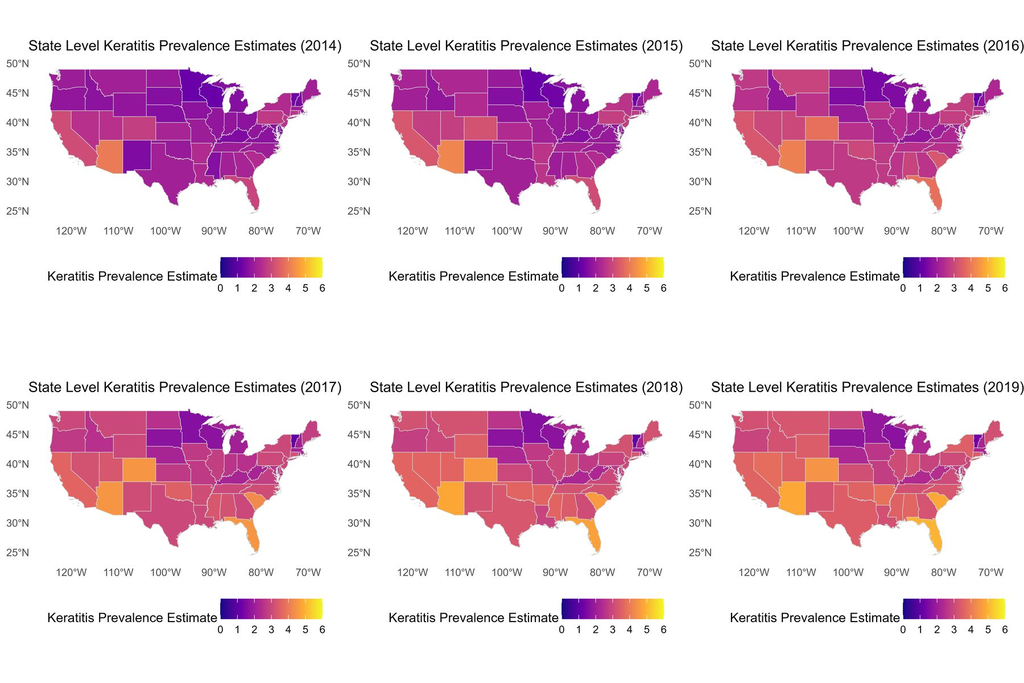

**Figure 1.** State-level keratitis prevalence estimates from 2014–2019, showing a broad increase across all states over the study period. Higher prevalence appears in the South and West.

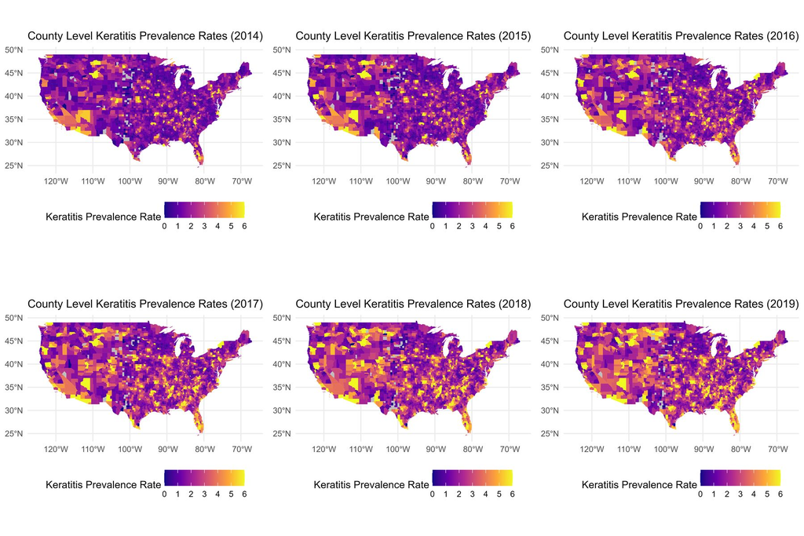

**Figure 2.** County-level keratitis prevalence, capped at 6%, revealing finer-grained geographic heterogeneity within states and across census regions.

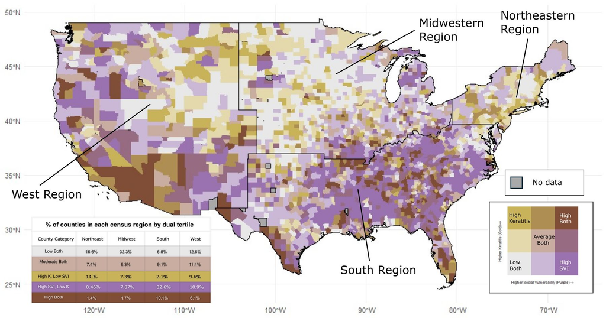

**Figure 3.** Bivariate choropleth map showing the intersection of keratitis prevalence and social vulnerability (SVI) across contiguous U.S. counties, 2014–2019 means. Brown tones indicate co-occurrence of high keratitis and high social vulnerability.

### Study 3 · In Preparation

## Keratitis in Florida & Social Vulnerability In Prep

Pshea-Smith IA, Bashshur RC, Ash KD. The Geography of Keratitis in the State of Florida and its Relationship with Social Vulnerability. In preparation for *GeoHealth*.

Building on the national analysis, this study focuses on the state of Florida, which had the highest keratitis prevalence of any U.S. state by 2019. We mapped county-level keratitis estimates across Florida from 2014–2019 and modeled their association with the CDC’s Social Vulnerability Index and its four constituent sub-themes.

2.9%

Mean keratitis prevalence across FL (2014–2019)

65 of 67

Counties showed increasing prevalence

β = 1.69

SVI Theme 1 (socioeconomic) association with keratitis

p < 0.001

Overall SVI–keratitis association

Geographic clusters of high keratitis prevalence were identified in the panhandle and south-central regions of the state. The strongest positive relationship with social vulnerability was found for SVI Theme 1 (socioeconomic status), consistent with existing literature linking poverty and limited healthcare access to keratitis burden. The study underscores that even within a single high-prevalence state, the distribution of keratitis is uneven and correlated with deprivation.

## Team & Affiliations

This work is a collaboration between Ramona Bashshur, Kevin Ash, Ethan Werner, Matthew Dunn, Pauline Dmitriev, Mary Bashshur, Wadad Itani, Zeinab K. Mofrad, and Elizabeth Stout.

[← Back to Main Site](https://ianpsheasmith.github.io)